# Homework 9

Maya Ziebarth

2024-02-19

## Instructions

Answer the following questions and complete the exercises in RMarkdown. Please embed all of your code and push your final work to your repository. Your final lab report should be organized, clean, and run free from errors. Remember, you must remove the `#` for the included code chunks to run. Be sure to add your name to the author header above.

Make sure to use the formatting conventions of RMarkdown to make your report neat and clean!

## Load the libraries

```r
library(tidyverse)
library(janitor)
library(here)
library(naniar)
```

For this homework, we will take a departure from biological data and use data about California colleges. These data are a subset of the national college scorecard (https://collegescorecard.ed.gov/data/). Load the `ca_college_data.csv` as a new object called `colleges`.

```r
colleges <- read_csv("data/ca_college_data.csv") %>% clean_names()
```

The variables are a bit hard to decipher, here is a key:

INSTNM: Institution name  
CITY: California city  
STABBR: Location state  
ZIP: Zip code  
ADM_RATE: Admission rate  
SAT_AVG: SAT average score  
PCIP26: Percentage of degrees awarded in Biological And Biomedical Sciences  
COSTT4_A: Annual cost of attendance  
C150_4_POOLED: 4-year completion rate  
PFTFTUG1_EF: Percentage of undergraduate students who are first-time, full-time degree/certificate-seeking undergraduate students

1. Use your preferred function(s) to have a look at the data and get an idea of its structure. Make sure you summarize NA’s and determine whether or not the data are tidy. You may also consider dealing with any naming issues.

```r
head(colleges)
```

```
## # A tibble: 6 × 10
##   instnm       city  stabbr zip   adm_rate sat_avg pcip26 costt4_a c150_4_pooled
##   <chr>        <chr> <chr>  <chr>    <dbl>   <dbl>  <dbl>    <dbl>         <dbl>
## 1 Grossmont C… El C… CA     9202…       NA      NA 0.0016     7956            NA
## 2 College of … Visa… CA     9327…       NA      NA 0.0066     8109            NA
## 3 College of … San … CA     9440…       NA      NA 0.0038     8278            NA
## 4 Ventura Col… Vent… CA     9300…       NA      NA 0.0035     8407            NA
## 5 Oxnard Coll… Oxna… CA     9303…       NA      NA 0.0085     8516            NA
## 6 Moorpark Co… Moor… CA     9302…       NA      NA 0.0151     8577            NA
## # ℹ 1 more variable: pftftug1_ef <dbl>
```

2. Which cities in California have the highest number of colleges?

```r
colleges %>%
  count(city, sort=T) #Los Angeles
```

```
## # A tibble: 161 × 2
##    city              n
##    <chr>         <int>
##  1 Los Angeles      24
##  2 San Diego        18
##  3 San Francisco    15
##  4 Sacramento       10
##  5 Berkeley          9
##  6 Oakland           9
##  7 Claremont         7
##  8 Pasadena          6
##  9 Fresno            5
## 10 Irvine            5
## # ℹ 151 more rows
```

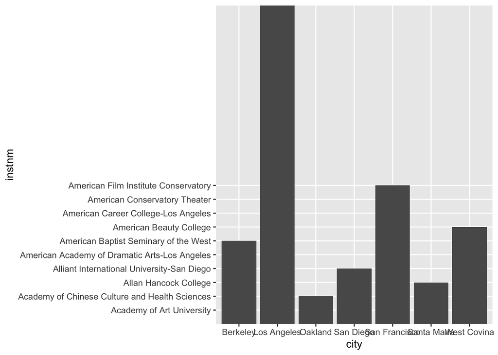

```r
colleges %>%
  select(instnm, city) %>%
  top_n(-10, instnm) %>%
  ggplot(aes(x=city, y=instnm)) +
  geom_col()
```

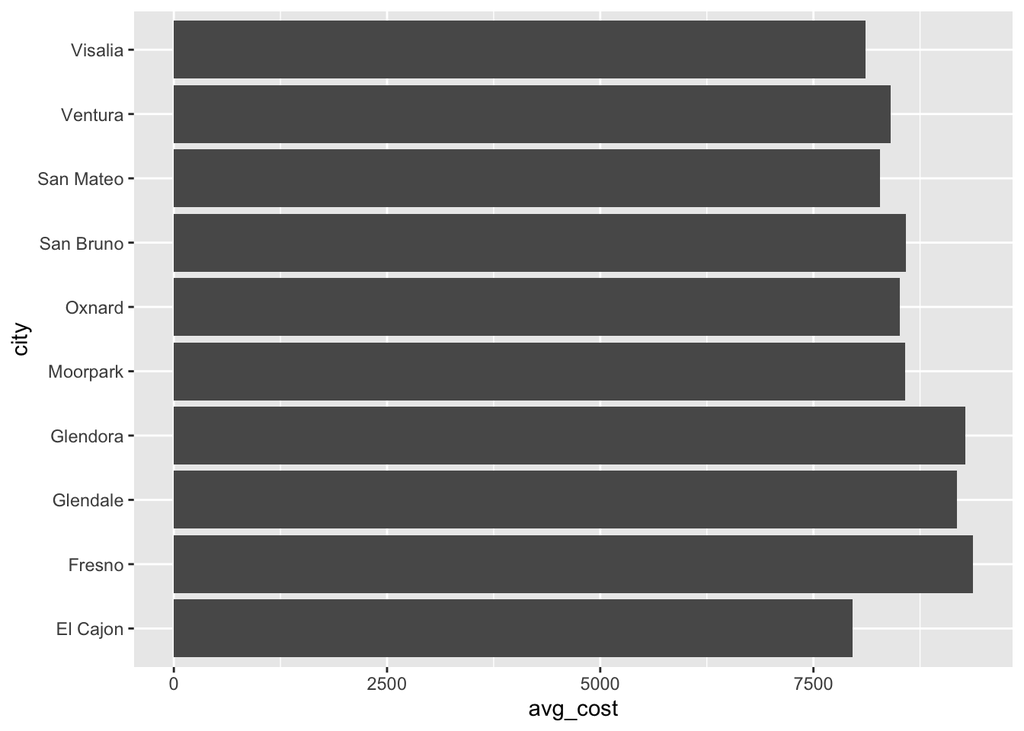

```r
colleges %>%
  select(city, costt4_a) %>%
  top_n(-10, costt4_a) %>%
  group_by(city) %>%
  summarize(avg_cost=mean(costt4_a, na.rm=T)) %>%
  ggplot(aes(x=city, y=avg_cost)) +
  geom_col(na.rm=T) +
  coord_flip()
```

5. Based on your answer to #4, make a plot that compares the cost of the individual colleges in the most expensive city. Bonus! Add UC Davis here to see how it compares :>).

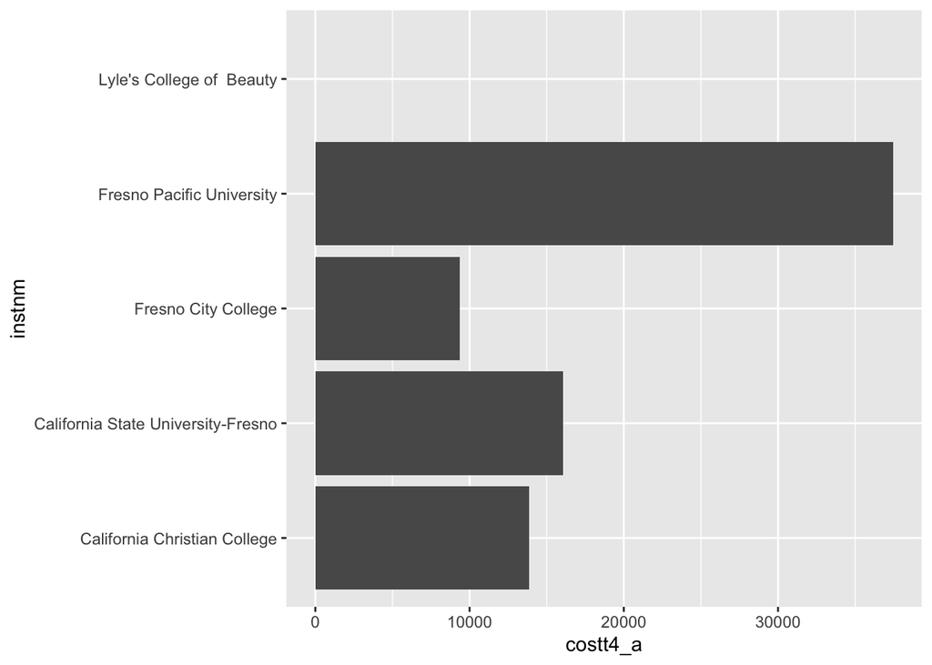

```r
colleges %>%
  filter(city=="Fresno") %>%
  ggplot(aes(x=instnm, y=costt4_a)) +
  geom_col(na.rm=T) +
  coord_flip()
```

6. The column `ADM_RATE` is the admissions rate by college and `C150_4_POOLED` is the four-year completion rate. Use a scatterplot to show the relationship between these two variables. What do you think this means?

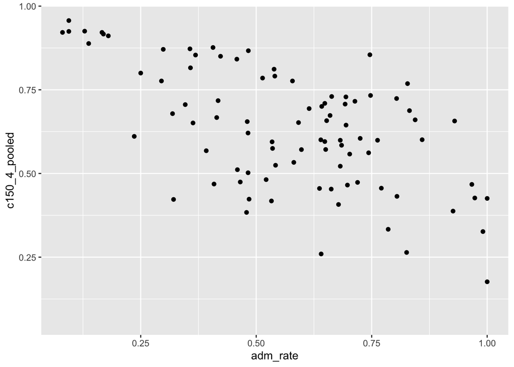

```r
colleges %>%
  ggplot(aes(x=adm_rate, y=c150_4_pooled)) +
  geom_point()
```

```r
# as admission rate increases, the 4 year completion rate goes down
```

7. Is there a relationship between cost and four-year completion rate? (You don’t need to do the stats, just produce a plot). What do you think this means?

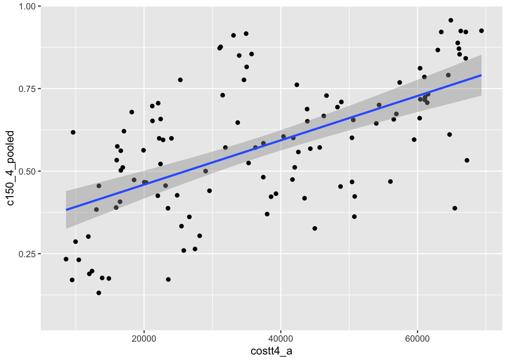

```r
colleges %>%
  ggplot(aes(x=costt4_a, y=c150_4_pooled)) +
  geom_point() +
  geom_smooth(method=lm, se=T)
```

```r
#As cost increases, the rate of completion after 4 years increases
```

8. The column titled `INSTNM` is the institution name. We are only interested in the University of California colleges. Make a new data frame that is restricted to UC institutions. You can remove `Hastings College of Law` and `UC San Francisco` as we are only interested in undergraduate institutions.

```r
uc_colleges <- colleges %>%
  filter_all(any_vars(str_detect(., pattern = "University of California")))
```

Remove `Hastings College of Law` and `UC San Francisco` and store the final data frame as a new object `univ_calif_final`.

```r
uc_colleges %>%
  filter(city!="San Francisco")
```

```
## # A tibble: 8 × 10
##   instnm       city  stabbr zip   adm_rate sat_avg pcip26 costt4_a c150_4_pooled
##   <chr>        <chr> <chr>  <chr>    <dbl>   <dbl>  <dbl>    <dbl>         <dbl>
## 1 University … La J… CA     92093    0.357    1324  0.216    31043         0.872
## 2 University … Irvi… CA     92697    0.406    1206  0.107    31198         0.876
## 3 University … Rive… CA     92521    0.663    1078  0.149    31494         0.73
## 4 University … Los … CA     9009…    0.180    1334  0.155    33078         0.911
## 5 University … Davis CA     9561…    0.423    1218  0.198    33904         0.850
## 6 University … Sant… CA     9506…    0.578    1201  0.193    34608         0.776
## 7 University … Berk… CA     94720    0.169    1422  0.105    34924         0.916
## 8 University … Sant… CA     93106    0.358    1281  0.108    34998         0.816
## # ℹ 1 more variable: pftftug1_ef <dbl>
```

Use `separate()` to separate institution name into two new columns “UNIV” and “CAMPUS”.

```r
uc_colleges %>%
  separate(instnm, into=c("univ", "campus"), sep="-")
```

```
## # A tibble: 10 × 11
##    univ               campus city  stabbr zip   adm_rate sat_avg pcip26 costt4_a
##    <chr>              <chr>  <chr> <chr>  <chr>    <dbl>   <dbl>  <dbl>    <dbl>
##  1 University of Cal… San D… La J… CA     92093    0.357    1324  0.216    31043
##  2 University of Cal… Irvine Irvi… CA     92697    0.406    1206  0.107    31198
##  3 University of Cal… River… Rive… CA     92521    0.663    1078  0.149    31494
##  4 University of Cal… Los A… Los … CA     9009…    0.180    1334  0.155    33078
##  5 University of Cal… Davis  Davis CA     9561…    0.423    1218  0.198    33904
##  6 University of Cal… Santa… Sant… CA     9506…    0.578    1201  0.193    34608
##  7 University of Cal… Berke… Berk… CA     94720    0.169    1422  0.105    34924
##  8 University of Cal… Santa… Sant… CA     93106    0.358    1281  0.108    34998
##  9 University of Cal… Hasti… San … CA     9410…   NA          NA NA           NA
## 10 University of Cal… San F… San … CA     9414…   NA          NA NA           NA
## # ℹ 2 more variables: c150_4_pooled <dbl>, pftftug1_ef <dbl>
```

9. The column `ADM_RATE` is the admissions rate by campus. Which UC has the lowest and highest admissions rates? Produce a numerical summary and an appropriate plot.

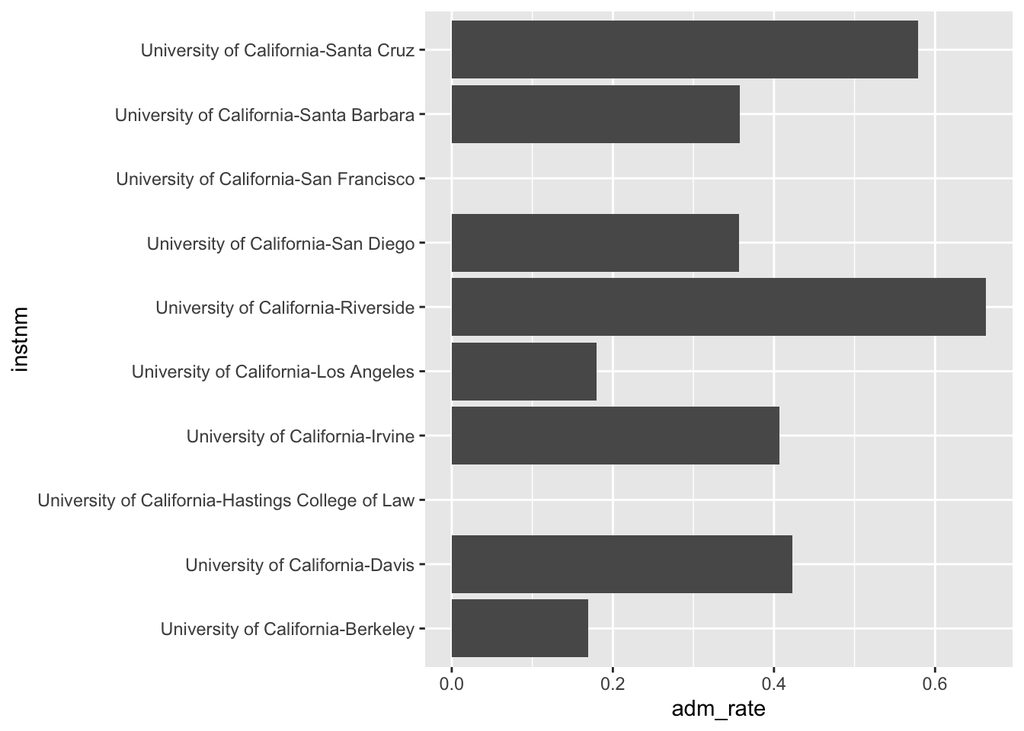

```r
uc_colleges %>%
  select(instnm, adm_rate) %>%
  ggplot(aes(x=instnm, y=adm_rate))+
  geom_col() +
  coord_flip()
```

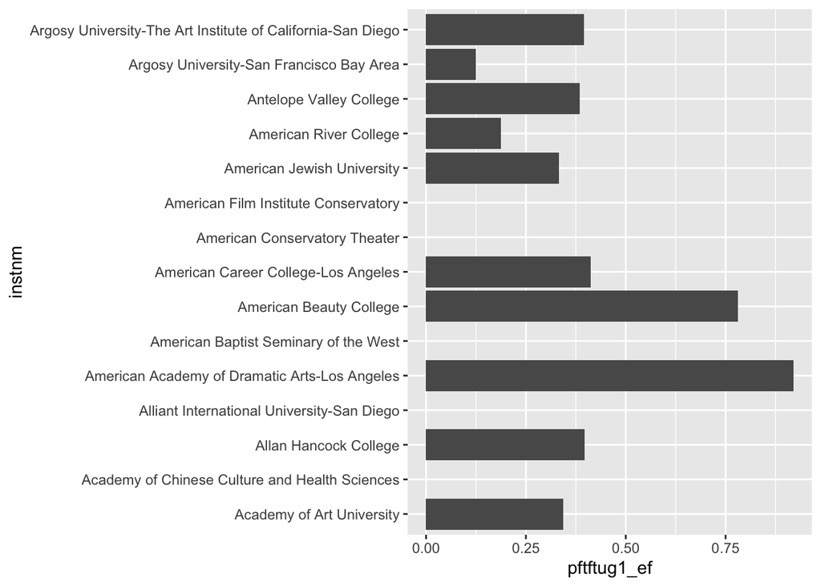

```r
colleges %>%
  select(instnm, pftftug1_ef) %>%
  top_n(-15, instnm) %>%
  ggplot(aes(x=instnm, y=pftftug1_ef))+
  geom_col()+
  coord_flip()
```

## Knit Your Output and Post to [GitHub](https://github.com/FRS417-DataScienceBiologists)